# Individual Project

# Distance Matrix

I will now create a distance matrix to further analyze the sequences

To begin I must convert HSubAlign from a DNAMultipleAlignment object to a DNAbin object

```r
HSubAlignBin = as.DNAbin(HSubAlign)
HDM = dist.dna(HSubAlignBin, model = "K80")
```

Now I will convert the martix from n x n to a linear matrix

```r
library(reshape2)
HDMmat = as.matrix(HDM)
dim(HDMmat)
```

```
## [1] 9 9
```

```r
PDat = melt(HDMmat)
dim(PDat)
```

```
## [1] 81  3
```

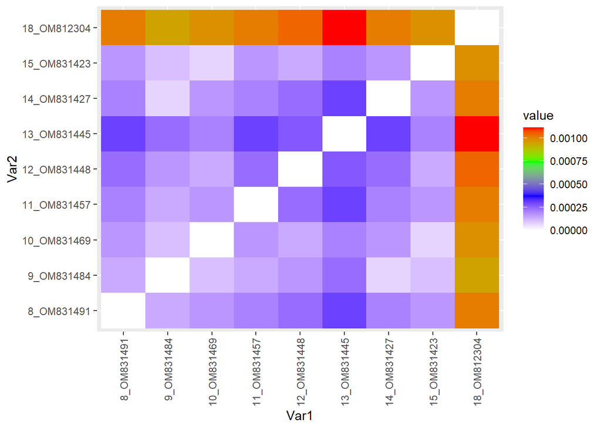

```r
PDat$value[PDat$value > 0.2] = NA
ggplot(data = PDat, aes(x = Var1, y = Var2, fill = value)) +
  geom_tile() +
    scale_fill_gradientn(colours = c("white", "blue", "green", "red")) +
  theme(axis.text.x = element_text(angle = 90, hjus = 1, vjust = 0.5))
```

As we can see based on this model, sequence 18 stands out greatly from the rest of the sequences.

# Tree Building

Now I will build a phylogeny tree based on the data I have collected

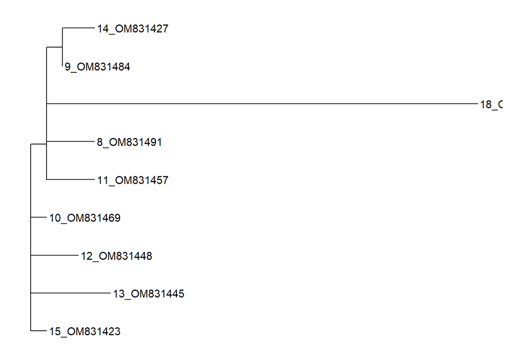

```r
HTree = nj(HDM)
library(ggtree)
ggtree(HTree, layout = "rectangular") +
  geom_tiplab()
```

I will save a copy of this tree for use later

```r
write.tree(HTree, "SARS-Cov-2-Tree.tre")
```